# Compute Canada

# Login information

**UserID:** 3106879  
**Username:** rwright  
**There are several general purpose clusters:**  
beluga.computecanada.ca  
cedar.computecanada.ca  
graham.computecanada.ca

**Logon beluga:**

```bash
ssh rwright@beluga.computecanada.ca
htop
```

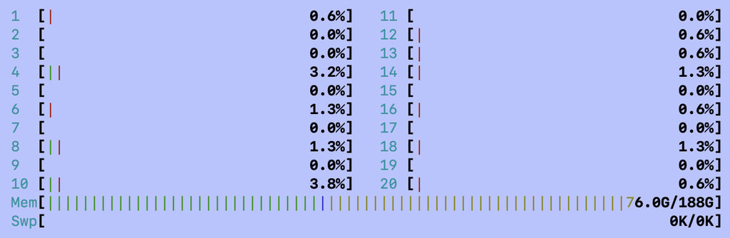

**Logon cedar:**

```bash
ssh rwright@cedar.computecanada.ca
htop
```

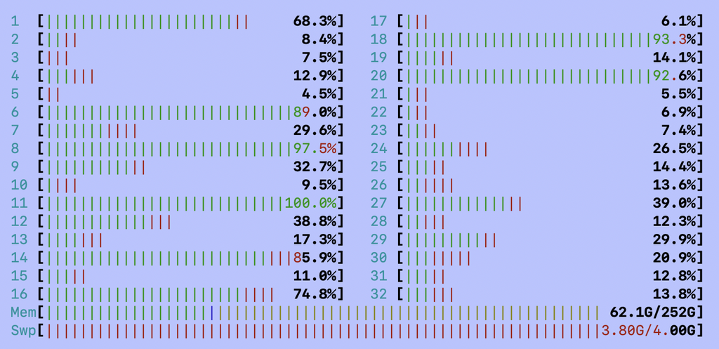

**Logon graham:**

```bash
ssh rwright@graham.computecanada.ca
htop
```

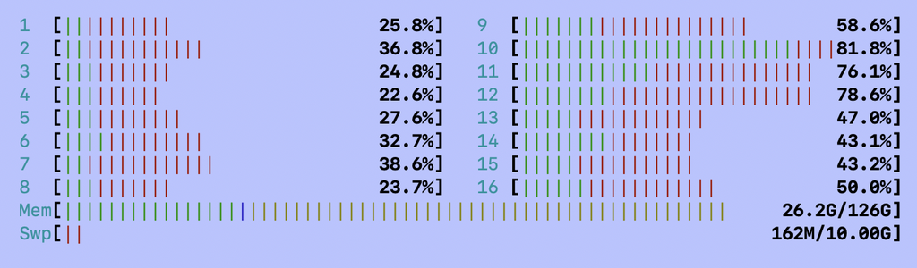

# Setup

## Install Anaconda

```bash
wget https://repo.anaconda.com/archive/Anaconda3-2020.11-Linux-x86_64.sh
bash Anaconda3-2020.11-Linux-x86_64.sh
export PATH=$PATH:/home/rwright/anaconda3/bin
```

## Create conda environment

```bash
conda create --name kneaddata
conda activate kneaddata
conda config --add channels defaults
conda config --add channels bioconda
conda config --add channels conda-forge
```

Remove conda environment:

```bash
conda remove --name kneaddata --all
```

## Install kneaddata packages

```bash
#pip install kneaddata
conda install -c bioconda kneaddata
conda install bowtie2
conda install -c bioconda trf
conda install -c cyclus java-jre
conda install -c bioconda fastqc
conda install -c bioconda samtools
```

## Download trimmomatic

Using the binary link [here](http://www.usadellab.org/cms/?page=trimmomatic)

```bash
mkdir tools
wget http://www.usadellab.org/cms/uploads/supplementary/Trimmomatic/Trimmomatic-0.39.zip
unzip Trimmomatic-0.39.zip
rm Trimmomatic-0.39.zip
```

## Install python packages

```bash
conda install -c jmcmurray os
conda install -c omnia subprocess32
conda install -c conda-forge pickle5
conda install numpy
conda install -c conda-forge biopython
conda install -c trentonoliphant datetime
conda install sys
```

# Run file

Initially tried on beluga but ran out of space, so have requested access to Niagara instead: `rwright@niagara.computecanada.ca`  
Misunderstood how to use beluga, I think it will have enough space to run things, just need to understand how to submit jobs (using sbatch).  
- Get bowtie2 database onto beluga - copy from vulcan using scp on vulcan  
- Rewrite run_participant script to work with an input of the participant number  
- Write a script that will submit a separate job for each  
- Test memory usage of kneaddata  
- Use of sbatch

## Test memory usage

**Run kneaddata on single lane (vulcan):**

```bash
(/usr/bin/time -v kneaddata -i PGPC_0014_S8_L008_R1.fastq -i PGPC_0014_S8_L008_R2.fastq -o kneaddata_out/ \
-db /home/shared/bowtiedb/GRCh38_PhiX --trimmomatic /home/robyn/tools/Trimmomatic-0.39/ \
-t 40 --trimmomatic-options "SLIDINGWINDOW:4:20 MINLEN:50" \
--bowtie2-options "--very-sensitive --dovetail" --remove-intermediate-output) 2> time.txt
```

**Output:**

```bash
Command being timed: "kneaddata -i PGPC_0014_S8_L008_R1.fastq -i PGPC_0014_S8_L008_R2.fastq -o kneaddata_out/ -db /home/shared/bowtiedb/GRCh38_PhiX --trimmomatic /home/robyn/tools/Trimmomatic-0.39/ -t 40 --trimmomatic-options SLIDINGWINDOW:4:20 MINLEN:50 --bowtie2-options --very-sensitive --dovetail --remove-intermediate-output"
        User time (seconds): 137957.97
        System time (seconds): 934.70
        Percent of CPU this job got: 1952%
        Elapsed (wall clock) time (h:mm:ss or m:ss): 1:58:34
        Average shared text size (kbytes): 0
        Average unshared data size (kbytes): 0
        Average stack size (kbytes): 0
        Average total size (kbytes): 0
        Maximum resident set size (kbytes): 20127516
        Average resident set size (kbytes): 0
        Major (requiring I/O) page faults: 0
        Minor (reclaiming a frame) page faults: 90714006
        Voluntary context switches: 1302969
        Involuntary context switches: 1034430
        Swaps: 0
        File system inputs: 949624263
        File system outputs: 450967953
        Socket messages sent: 0
        Socket messages received: 0
        Signals delivered: 0
        Page size (bytes): 4096
        Exit status: 0
```

So maximum resident set size = 20127516 KB = 20.12GB  
So setting maximum memory as 50GB

## Using sbatch and slurm

**Submit job:** `sbatch $job_file.sh`  
**Check status of jobs:** `sq` (only for this user)  
*Example output:*

```
JOBID     USER      ACCOUNT           NAME  ST  TIME_LEFT NODES CPUS TRES_PER_N MIN_MEM NODELIST (REASON)
15017983  rwright def-mlangill  PGPC_0015.job  PD 1-00:00:00     1   40        N/A     50G  (Priority)
15017984  rwright def-mlangill  PGPC_0016.job  PD 1-00:00:00     1   40        N/A     50G  (Priority)
```

**Check status of jobs:** `squeue` (all users)  
**Check output from a completed job:** `seff $JOBID`  
*Example output:*

```
(base) [rwright@beluga2 scratch]$ seff 15016870
Job ID: 15016870
Cluster: beluga
User/Group: rwright/rwright
State: FAILED (exit code 1)
Nodes: 1
Cores per node: 40
CPU Utilized: 00:00:00
CPU Efficiency: 0.00% of 00:02:00 core-walltime
Job Wall-clock time: 00:00:03
Memory Utilized: 319.00 KB
Memory Efficiency: 0.00% of 50.00 GB
```

**Cancel a job:** `scancel $JOBID` (If you asked for emails when things happened then this will send you an email saying the job got cancelled)

## Write a script that will submit a separate job for each

First:

```bash
#!/bin/bash

job_directory=$PWD
participants=("PGPC_0015" "PGPC_0016")

for participant in ${participants[@]}; do

    job_file="${job_directory}/${participant}.job"

    echo "#!/bin/bash
#SBATCH --job-name=${participant}.job
#SBATCH --output=$PWD/out/${participant}.out
#SBATCH --error=$PWD/out/${participant}.err
#SBATCH --time=1-00:00
#SBATCH --mem=50G
#SBATCH --cpus-per-task=40
#SBATCH --mail-user=robyn.wright@dal.ca
#SBATCH --mail-type=ALL
python run_single_participant.py ${participant}" > $job_file
    sbatch $job_file

done
```

This is in the file `run_all_jobs.sh`

Second/final (switched to python):

```python
import os
import subprocess
import pickle
import numpy as np
from Bio import SeqIO
from datetime import datetime
import sys

job_directory = '/home/rwright/scratch/'
#participant_names = ['PGPC_0015', 'PGPC_0016', 'PGPC_0017', 'PGPC_0018', 'PGPC_0019', 'PGPC_0020', 'PGPC_0021', 'PGPC_0022', 'PGPC_0023', 'PGPC_0024', 'PGPC_0025', 'PGPC_0026', 'PGPC_0027', 'PGPC_0028', 'PGPC_0029', 'PGPC_0030', 'PGPC_0031', 'PGPC_0032', 'PGPC_0033', 'PGPC_0034', 'PGPC_0035', 'PGPC_0036', 'PGPC_0037', 'PGPC_0038', 'PGPC_0039', 'PGPC_0040', 'PGPC_0041', 'PGPC_0042', 'PGPC_0043', 'PGPC_0044', 'PGPC_0045', 'PGPC_0046', 'PGPC_0047', 'PGPC_0048', 'PGPC_0049', 'PGPC_0050', 'PGPC_0051', 'PGPC_0052', 'PGPC_0053', 'PGPC_0054', 'PGPC_0055', 'PGPC_0056', 'PGPC_0057', 'PGPC_0059', 'PGPC_0061', 'PGPC_0062', 'PGPC_0067', 'PGPC_0069', 'PGPC_0070', 'PGPC_0071', 'PGPC_0072', 'PGPC_0073', 'PGPC_0074', 'PGPC_0076', 'PGPC_0077', 'PGPC_0078', 'PGPC_0082', 'PGPC_0087']
participant_names = ['PGPC_0015', 'PGPC_0016', 'PGPC_0017', 'PGPC_0018', 'PGPC_0019', 'PGPC_0020']
direc = '/home/rwright/scratch/'

with open(direc+'participant_links.dict', 'rb') as f:
    participants = pickle.load(f)

with open(direc+'file_names.dict', 'rb') as f:
    file_names = pickle.load(f)

for participant in participant_names:
    if participant != 'PGPC_0015': continue
    str = '#!/bin/bash\n'
    str += '#SBATCH --job-name='+participant+'.job\n'
    str += '#SBATCH --output='+job_directory+'out/'+participant+'.out\n'
    str += '#SBATCH --error='+job_directory+'out/'+participant+'.err\n'
    str += '#SBATCH --time=1-00:00\n'
    str += '#SBATCH --mem=50G\n'
    str += '#SBATCH --cpus-per-task=40\n'
    str += '#SBATCH --mail-user=robyn.wright@dal.ca\n'
    str += '#SBATCH --mail-type=ALL\n'
    str += 'source /home/rwright/.bashrc\n'
    str += 'conda activate kneaddata\n'
    str += 'source activate kneaddata\n'
    os.system('mkdir '+direc+participant)
    for link in participants[participant]:
        if not os.path.exists(direc+participant+'/'+file_names[link].replace('_001.', '.')):
            os.system('wget '+link+' -O '+direc+participant+'/'+file_names[link].replace('_001.', '.'))
    str += 'python run_single_participant.py '+participant+'\n'
    with open(participant+'.job', 'w') as f:
        f.write(str)
    os.system('sbatch '+participant+'.job')
```

This is in the file `run_all_jobs.py`

### Problems

Initially had trouble because wget doesn’t work within the sbatch script - “connection refused” error. It’s the same if I call it from python or use alternative python packages for download.  
So I switched to downloading from the initial python script used to generate the sbatch files and then submitting the job after all files are downloaded, but now I’m having issues with kneaddata:

```
Traceback (most recent call last):
  File "/home/rwright/anaconda3/envs/kneaddata/bin/kneaddata", line 8, in <module>
    sys.exit(main())
  File "/home/rwright/anaconda3/envs/kneaddata/lib/python3.8/site-packages/kneaddata/knead_data.py", line 427, in main
    args.input[index]=utilities.get_reformatted_identifiers(args.input[index],args.output_dir, temp_output_files)
  File "/home/rwright/anaconda3/envs/kneaddata/lib/python3.8/site-packages/kneaddata/utilities.py", line 258, in get_reformatted_identifiers
    os.write(file_out, "".join(lines))
TypeError: a bytes-like object is required, not 'str'
```

Test kneaddata:

```bash
kneaddata -i PGPC_0015_S1_L003_R1.fastq -i PGPC_0015_S1_L003_R2.fastq -o kneaddata_out/ \
-db /home/rwright/scratch/bowtie_db/GRCh38_PhiX --trimmomatic /home/rwright/tools/Trimmomatic-0.39/ \
-t 20 --trimmomatic-options "SLIDINGWINDOW:4:20 MINLEN:50" \
--bowtie2-options "--very-fast --dovetail" --remove-intermediate-output
```

Get the same problem.

Test same on vulcan (using the same files but copied across):

```bash
kneaddata -i PGPC_0015_S1_L003_R1.fastq -i PGPC_0015_S1_L003_R2.fastq -o kneaddata_out/ \
-db /home/shared/bowtiedb/GRCh38_PhiX --trimmomatic /home/robyn/tools/Trimmomatic-0.39/
```

Works fine  
So trying out an interactive job:

```bash
(kneaddata) [rwright@beluga1 scratch]$ salloc --time=1:0:0 --ntasks=20 --mem-per-cpu 50G
salloc: Pending job allocation 15038192
salloc: job 15038192 queued and waiting for resources
```

Same error.  
Reinstalled kneaddata using conda (initially had only used pip):

```bash
(kneaddata) [rwright@blg6150 PGPC_0015]$ kneaddata -i PGPC_0015_S1_L003_R1.fastq -i PGPC_0015_S1_L003_R2.fastq -o kneaddata_out/ -db /home/rwright/scratch/bowtie_db/GRCh38_PhiX --trimmomatic /home/rwright/tools/Trimmomatic-0.39/ -t 20 --trimmomatic-options "SLIDINGWINDOW:4:20 MINLEN:50" --bowtie2-options "--very-fast --dovetail" --remove-intermediate-output
Reformatting file sequence identifiers ...

Reformatting file sequence identifiers ...

Initial number of reads ( /lustre04/scratch/rwright/PGPC_0015/kneaddata_out/reformatted_identifiers7yj6vsd3_PGPC_0015_S1_L003_R1 ): 41149022.0
```

And then I stopped it. Going to retry now within the script.  
And exit the `salloc` interactive job: `exit`  
And then I tried submitting the job again, but this time I get this error:

```bash
Error message returned from Trimmomatic :
<JAVA_HOME>/lib/ext exists, extensions mechanism no longer supported; Use -classpath instead.
.Error: Could not create the Java Virtual Machine.
Error: A fatal exception has occurred. Program will exit.
```

So I’m going to remove the conda environment and start again - maybe there was a problem from having installed kneaddata more than once and what is used as default etc.  
Removed and reinstalled everything. Added python packages to initial script to make sure that they import fine.  
This ran and all lanes from that participant ran. Output:

```
(base) [rwright@beluga2 scratch]$ seff 15043042
Job ID: 15043042
Cluster: beluga
User/Group: rwright/rwright
State: COMPLETED (exit code 0)
Nodes: 1
Cores per node: 40
CPU Utilized: 9-03:04:38
CPU Efficiency: 40.63% of 22-11:14:40 core-walltime
Job Wall-clock time: 13:28:52
Memory Utilized: 14.69 GB
Memory Efficiency: 29.39% of 50.00 GB
```

Lowered the maximum time from 1 day to 15 hours and the maximum memory from 50GB to 25GB and set participants 16-25 to run.